# Exploring the NHTS with R

AnthonyFucci@Westat.com  
AlexanderCates@Westat.com  
summarizeNHTS

Wednesday, August 8, 2018

# Overview

**Workshop Goals**

- Demonstrate how to work with NHTS data in R
- Generate national travel estimates with statistical confidence
- Create a publish-ready report with estimates and visuals from today’s workshop
- **Preview the report we are going to create**

# Topics

1. Setting Up an R Analysis Environment
2. Accessing the Data
3. Generating Estimates
4. Creating New Variables
5. Visualizing Estimates
6. Producing a Travel Analysis Report

# “House Cleaning”

- 1 hour!?
- Write your questions down
- This presentation is reproducible
- Take it with you, download it later, go at your own pace

**This presentation is intended for re-use**

- Focus on the presentation itself today  
  ↪ Later, follow along in RStudio at your own pace

**Presentation hotkeys**

| Key | Action |
| --- | --- |
| C | Show table of contents |
| F | Toggles the display of the footer |
| A | Toggles display of current vs all slides |
| S | Make fonts smaller |
| B | Make fonts larger |

# Next Topic

1. **Setting Up an R Analysis Environment**
2. Accessing the Data
3. Generating Estimates
4. Creating New Variables
5. Visualizing Estimates
6. Producing a Travel Analysis Report

# Setting Up an R Analysis Environment

**[Click here for latest installation instructions](https://github.com/Westat-Transportation/summarizeNHTS/tree/master/inst/install)**

**Instructions provide explicit download links for**

- R
- R Tools
- RStudio

**Once installed, open RStudio**

# Setting Up an R Analysis Environment (cont.)

**Make sure you have the “summarizeNHTS” R software package installed**

```r
install.packages("devtools")
devtools::install_github("Westat-Transportation/summarizeNHTS")
```

**And now that we have installed the necessary software, load the software**

```r
library(summarizeNHTS)
```

**OK, we’re ready!**

- Your R environment for NHTS analysis is set up
- You only need to set up an environment once
- From now on, just open RStudio and load summarizeNHTS

# Next Topic

1. Setting Up an R Analysis Environment
2. **Accessing the Data**
3. Generating Estimates
4. Creating New Variables
5. Visualizing Estimates
6. Producing a Travel Analysis Report

# Accessing the Data

- Instructions for downloading the data
- Read the 2017 data into our R enviornment
- Explore the data structure and object content
- Select a subset of an NHTS data table
- Explore the codebook in R

**Before we begin, let’s make sure the `summarizeNHTS` package is loaded.**

```r
library(summarizeNHTS)
```

# Accessing the Data: Downloading NHTS Data

```r
# Not Run
download_nhts_data("2001")
download_nhts_data("2009")
download_nhts_data("2017")
```

- You can download the 2001, 2009, and 2017 using the `download_nhts_data` function.
  - Downloads directly from the [Oak Ridge NHTS website](https://nhts.ornl.gov/downloads).
- `download_nhts_data` parameters
  - Dataset year
  - Dataset directory (defaults to current working directory)
- Recommend creating an RStudio Project and using the project directory.

# Accessing the Data: Reading the 2017 NHTS data

```r
nhts_data <- read_data("2017", "C:/NHTS")
```

- `read_data` is a function that reads and compiles data from CSVs.
  - Data files are packaged up (in memory) as an R object.
  - Any alterations to this object *will NOT affect the CSVs.*
- `nhts_data` is the new object we created.
  - Note: It can be named anything (within R’s syntax rules).
- Which NHTS dataset?
  - Pass `'2017'` to specify that we are working with the 2017 dataset.
  - Can specify directory where the data is stored (recall the `download_nhts_data` function).

# Accessing the Data: Summarizing the data object

- The data / weights are contained within the `nhts_data` object we created.
  - Access these contents using `$`
- Use the `summary` function to get an overview of the data structure.

```r
summary(nhts_data$data)
```

```
##           Length Class      Mode
## trip      60     data.table list
## person    87     data.table list
## household 59     data.table list
## vehicle   15     data.table list
```

- The contents of the `data` element include four `data.table` objects:
  - trip
  - person
  - household
  - vehicle
- `data.tables` are 2-dimensional data structures (rows X columns).
  - An extension of R’s base `data.frame` structure (with enhanced functionality).
- The length refers to the number of columns in each table.

# Accessing the Data: Snapshot of the vehicle data

- How do I access the raw data?
- Let’s hop over to Rstudio to explore in more detail

```r
nhts_data$data$vehicle
```

```
##          HOUSEID VEHID ANNMILES FUELTYPE HFUEL HYBRID MAKE MODEL OD_READ
##      1: 30000007    01     1000       01    -1     02   49 49032   69000
##      2: 30000007    02     2500       01    -1     02   49 49442  164000
##      3: 30000007    03      900       01    -1     02   19 19014  120000
##      4: 30000007    04      500       01    -1     02   19 19021     -88
##      5: 30000007    05    10000       01    -1     02   20 20481  300000
##     ---
## 256111: 40794301    01     9500       01    -1     02   37 37441   60976
## 256112: 40794301    02     9600       01    -1     02   49 49032   93388
## 256113: 40794301    03     6200       01    -1     02   35 35443  143616
## 256114: 40794301    04       -1       01    -1     02   49 49471  195078
## 256115: 40794301    05     1000       01    -1     02   35 XXXXX  167141
##         VEHAGE VEHOWNED VEHOWNMO VEHTYPE VEHYEAR WHOMAIN
##      1:     10       01       -1      01    2007      03
##      2:     13       01       -1      02    2004      -8
##      3:     19       01       -1      01    1998      01
##      4:     20       01       -1      01    1997      02
##      5:     24       01       -1      04    1993      02
##     ---
## 256111:      5       01       -1      02    2012      01
## 256112:     12       02       10      01    2005      04
## 256113:     21       01       -1      02    1996      03
## 256114:     26       01       -1      04    1991      02
## 256115:     27       01       -1      01    1990      01
```

# Accessing the Data: Subsetting

- Select specific columns

```r
# By position
nhts_data$data$vehicle[, c(1, 3)]

# By name (single variable)
nhts_data$data$vehicle$ANNMILES

# By name
nhts_data$data$vehicle[, list(HOUSEID, ANNMILES)]
```

- Select specific rows

```r
# By row numbers (first 5 rows)
nhts_data$data$vehicle[1:5, ]

# By condition
nhts_data$data$vehicle[VEHTYPE == "01", ]

# By condition (multiple values)
nhts_data$data$vehicle[VEHTYPE %in% c("01","02"), ]
```

- *Note: Conditional subsetting will be revisited in the “Generating Estimates” secition.*
- Putting it together
  - Live example: print the MAKE and MODEL of vehicles from year 2012

# Accessing the Data: Codebook objects

- Access the variables and values tables for different years
  - `codebook_2001`, `codebook_2009`, `codebook_2017`

```r
# 2017 variables table
head(codebook_2017$variables)
```

```
##        NAME     TABLE      TYPE
## 1: AGERANGE    person character
## 2:  AIRPORT household character
## 3:    ALT_1    person character
## 4:   ALT_16    person character
## 5:    ALT_2    person character
## 6:   ALT_23    person character
##                                                                                  LABEL
## 1:                                                                           Age Range
## 2:                                                         Influence Choice of Airport
## 3:                           Alternative Mode of Transportation: Public Transportation
## 4:                   Alternative Mode of Transportation: Public Transportation or Taxi
## 5:            Alternative Mode of Transportation: Passenger to Friend or Family Member
## 6: Alternative Mode of Transportation: Passenger to Friend/Family Member or Rental Car
```

```r
# 2017 values table
head(codebook_2017$values)
```

```
##        NAME VALUE                  LABEL
## 1: AGERANGE    -8           I don't know
## 2: AGERANGE    -7 I prefer not to answer
## 3: AGERANGE    -1       Appropriate skip
## 4: AGERANGE    01          0-4 years old
## 5: AGERANGE    02         5-15 years old
## 6: AGERANGE    03        16-17 years old
```

# Next Topic

1. Setting Up an R Analysis Environment
2. Accessing the Data
3. **Generating Estimates**
4. Creating New Variables
5. Visualizing Estimates
6. Producing a Travel Analysis Report

# Generating Estimates

- Introduction to the `summarize_data` function
- Understanding `summarize_data` parameters
- Statistics grouped by variables
- Exploring aggregation options
- Estimates using a subset condition
- Referencing the documentation

# Generating Estimates: Introduction to `summarize_data`

- The `summarizeNHTS` package has built in functions for running complex queries on the NHTS dataset
- `summarize_data` is the workhorse function behind these queries.

```r
summarize_data(
  data = nhts_data,
  agg = "household_count"
)
```

```
##            W            E      S      N
## 1: 118208251 1.186759e-07 129696 129696
```

- What do these values mean?
  - **W - Weighted statistic.**
    - Count of households weighted to the population
  - **E - Standard error of the weighted statistic.**
    - Standard error of the weighted count of households
  - **S - Surveyed/sampled statistic (unweighted statistic).**
    - The count of sampled households
  - **N - Number of observations/sample size.**
    - The number of observations is the same as the count of sampled households in this example
- Every `summarize_data` query will return these fields.

# Generating Estimates: Exploring `summarize_data` Parameters

```r
summarize_data(
  data = nhts_data,
  agg = "household_count"
)
```

- Required parameters
  - `data` - NHTS dataset object
    - Will always be the output of `read_data`.
    - In our example, we stored the output in the `nhts_data` object.
  - `agg` - Aggregate function label
    - Our example used `'household_count'` but `agg` could be a number of other labels.
- Let’s explore some of the additional parameters!
  - Categorical grouping
  - Aggregation options
  - Subset conditions
  - More…

# Generating Estimates: Grouping by Variables

- What if I wanted to group these statistics by another variable?
  - Let’s use the `by` parameter to group by metropolitan status.

```r
summarize_data(
  data = nhts_data,
  agg = "household_count",
  by = "IS_METRO"
)
```

```
##                   IS_METRO         W        E      S      N
## 1:       Metropolitan Area 100480095 37143.09 109250 109250
## 2: Not a Metropolitan Area  17728156 37143.09  20446  20446
```

- You can specify any number of variables using the `by` parameter.

```r
summarize_data(
  data = nhts_data,
  agg = "household_count",
  by = c("IS_METRO","HOMEOWN")
)
```

```
##                   IS_METRO                HOMEOWN            W          E
## 1:       Metropolitan Area            I dont know     1728.364   1060.471
## 2:       Metropolitan Area I prefer not to answer    31126.577  10432.815
## 3:       Metropolitan Area                    Own 62154931.751 122801.012
## 4:       Metropolitan Area                   Rent 37328199.616 124577.033
## 5:       Metropolitan Area Some other arrangement   964108.222  87850.539
## 6: Not a Metropolitan Area I prefer not to answer     5866.829   4255.033
## 7: Not a Metropolitan Area                    Own 12363614.703 124022.494
## 8: Not a Metropolitan Area                   Rent  5135781.233 113252.628
## 9: Not a Metropolitan Area Some other arrangement   222893.706  36387.468
##        S     N
## 1:     3     3
## 2:    26    26
## 3: 81923 81923
## 4: 26568 26568
## 5:   730   730
## 6:     6     6
## 7: 16536 16536
## 8:  3700  3700
## 9:   204   204
```

# Generating Estimates: Frequencies/Proportions

- You can use any of the following count aggregates
  - `'household_count'`, `'person_count'`, `'trip_count'`, `'vehicle_count'`

```r
# Person count
summarize_data(
  data = nhts_data,
  agg = "person_count"
)
```

```
##            W        E      S      N
## 1: 301599169 0.390838 264234 264234
```

- You can also choose to view counts as a proportion of the total using the `prop` parameter
  - Only useful when a `by` variable is specified

```r
# Proportion of persons by WORKER, worker status
summarize_data(
  data = nhts_data,
  agg = "person_count",
  by = "WORKER",
  prop = TRUE
)
```

```
##              WORKER            W            E            S      N
## 1:  Not ascertained 6.819779e-05 2.760915e-05 6.433691e-05     17
## 2: Appropriate skip 1.508504e-01 1.263185e-03 1.057320e-01  27938
## 3:              Yes 5.205195e-01 1.690699e-03 4.855091e-01 128288
## 4:               No 3.285619e-01 2.475022e-03 4.086946e-01 107991
```

# Generating Estimates: Numeric Aggregates

- You can use any of the following numeric aggregates
  - `'sum'`, `'avg'`, `'median'`
- Must also specify a variable name using the `agg_var` parameter
  - Required that the variable be **numeric**

```r
# Average TRPMILES, trip distance in miles
summarize_data(
  data = nhts_data,
  agg = "avg",
  agg_var = "TRPMILES"
)
```

```
##           W         E        S      N
## 1: 10.70435 0.2003875 11.45057 922916
```

**Notes**

- `summarize_data` handles missing value (-1,-7,-8,-9) exclusion for numeric aggregates
- The N in the example above refers to the number of trips used in the calculation

# Generating Estimates: Trip Rates

- You can use either of the following trip rate aggregates
  - `'household_trip_rate'` - Daily Person Trips per Household
  - `'person_trip_rate'` - Daily Person Trips per Person

```r
# Daily person Trips by worker status
summarize_data(
  data = nhts_data,
  agg = "person_trip_rate",
  by = "WORKER"
)
```

```
##              WORKER        W          E        S      N
## 1:  Not ascertained 1.280018 1.11437619 1.647059     28
## 2: Appropriate skip 2.780250 0.03060904 2.838249  79295
## 3:              Yes 3.773681 0.01752420 3.881454 497944
## 4:               No 3.006374 0.02919963 3.206795 346305
```

# Generating Estimates: Subsetting in `summarize_data`

- Pre-aggregation subset conditions can be specified using the `subset` parameter.
  - Argument should be passed as a string.
- Subsetting character variables

```r
# Distribution of social/recreational trips by travel day
summarize_data(
  data = nhts_data,
  agg = "trip_count",
  by = "TRAVDAY",
  prop = TRUE,
  subset = "WHYTRP90 %in% c('07','08','10')"
)
```

```
##      TRAVDAY         W           E         S     N
## 1:    Sunday 0.1735797 0.003073281 0.1335907 33043
## 2:    Monday 0.1179881 0.002790327 0.1299642 32146
## 3:   Tuesday 0.1097795 0.001604585 0.1308981 32377
## 4: Wednesday 0.1123670 0.002679049 0.1350300 33399
## 5:  Thursday 0.1243485 0.003190797 0.1427399 35306
## 6:    Friday 0.1526481 0.003741184 0.1695486 41937
## 7:  Saturday 0.2092892 0.004953279 0.1582284 39137
```

- Subsetting numeric variables

```r
# Person trip rate by Sex (for millennials)
summarize_data(
  data = nhts_data,
  agg = "person_trip_rate",
  by = "R_SEX",
  subset = "R_AGE >= 18 & R_AGE <= 34"
)
```

```
##                     R_SEX         W          E        S     N
## 1:            I dont know 0.9505731 1.09495843 1.333333     4
## 2: I prefer not to answer 3.4089751 0.63080999 3.647059   124
## 3:                   Male 3.1543275 0.04725515 3.262248 63591
## 4:                 Female 3.4506053 0.05616977 3.590901 77427
```

# Generating Estimates: Documentation

- Comprehensive function documentation is accessible within R!

```r
?summarize_data
```

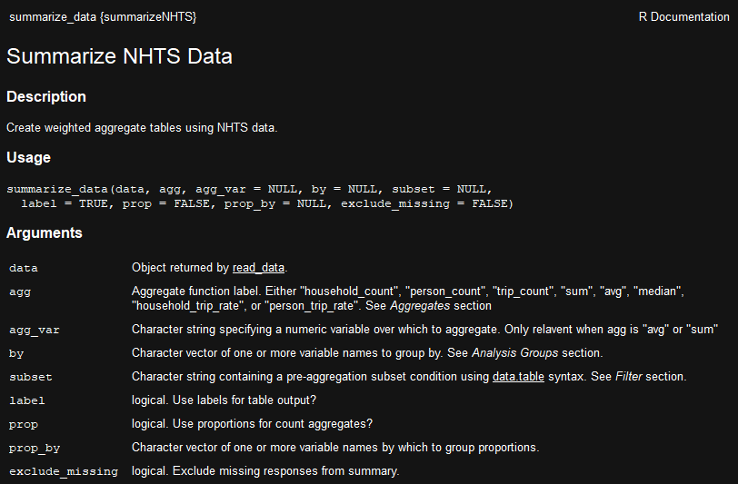

R Documentation for `summarize_data`

# Next Topic

1. Setting Up an R Analysis Environment
2. Accessing the Data
3. Generating Estimates
4. **Creating New Variables**
5. Visualizing Estimates
6. Producing a Travel Analysis Report

# Creating New Variables

- Derive information from other variables in the dataset
- Find new ways to to expand your analysis
- Types of derived variables include:
  - Flags (yes/no, is/is-not, has/has-not, etc)
  - Collapsing/Binning (e.g. grouping Bus and Rail into one Public Transit value)
  - (re)Categorization (manipulating categorical values to fit your needs)
  - Mathematical Calculations (variable * factor, variable / variable, etc)

# Creating New Variables: Example Scenario

**Example Derived Variable Coding Scenario**

1. Someone’s interested in querying the NHTS for a particular travel behavior

Anthony: “I am interested in exploring how financial burden may affect travel.”  
Alex: “Remember that question about walking to save money? I would include that in your analysis.”

2. Consider suggested variable’s usefulness for Anthony’s analysis:

*WALK2SAVE: “I walk to places to save money.”*

Values:

| 01 | Strongly agree |
| --- | --- |
| 02 | Agree |
| 03 | Neither Agree or Disagree |
| 04 | Disagree |
| 05 | Strongly disagree |

3. Look for potential other ways of maniupulating this variable for analysis
4. Create variable called WALK_FINANCE, a yes/no variable for the binary analysis question, “who does or does not walk to save money?”

# Creating New Variables: Configuration

- A derived variable template file is included in summarizeNHTS
- Create basic and complex variables with your own logic
- Variables loaded automatically for you by read_data()
- The derived variable template file preserves details of coding for your documentation

# Creating New Variables: Configuration (cont.)

**Derived variable file requirements**

| Item | Description |
| --- | --- |
| NAME | The name of the variable as it will appear in the dataset |
| TABLE | The table level this variable is being computed for |
| TYPE | Data type (numeric or character) |
| DOMAIN | Logical expression that decides value assignment |
| VALUE | A variable code value |
| LABEL | Description of code value |

**Review File**

# Creating New Variables: Example 1 (Has/Has-not)

**Using the Derived Variables file, create a variable with the following requirements:**

- Level: Household
- Idea: Household has at least one vehicle
- Values: 1=Yes, 2=No
- Name: HAS_VEHICLE

| NAME | TABLE | TYPE | DOMAIN | VALUE | LABEL |
| --- | --- | --- | --- | --- | --- |
| HAS_VEHICLE | household | character | HHVEHCNT > 0 | 1 | Yes |
| HAS_VEHICLE | household | character | HHVEHCNT == 0 | 2 | No |

# Creating New Variables: Example 2 (Grouping)

**Using the Derived Variables file, create a variable with the following requirements:**

- Level: Person
- Idea: Person age categorized into four large groups
- Values: 0 to 17 = Child, 18 to 44 = Young Adult, 45 to 65 = Middle Adult, 66 and up = Older Adult
- Name: AGE_GROUP

| NAME | TABLE | TYPE | DOMAIN | VALUE | LABEL |
| --- | --- | --- | --- | --- | --- |
| AGE_GROUP | person | character | R_AGE >= 0 & R_AGE <= 17 | 1 | Child |
| AGE_GROUP | person | character | R_AGE >= 18 & R_AGE <= 44 | 2 | Young Adult |
| AGE_GROUP | person | character | R_AGE >= 45 & R_AGE <= 65 | 3 | Middle Adult |
| AGE_GROUP | person | character | R_AGE >= 66 | 4 | Older Adult |

# Creating New Variables: Example 3 (Uses/Does-not-use)

**Using the Derived Variables file, create a variable with the following requirements:**

- Level: Person
- Idea: Person reports using a transportation network company (Uber/Lyft) in the last 30 days
- Values: 1=Yes, 2=No
- Name: USES_TNC

| NAME | TABLE | TYPE | DOMAIN | VALUE | LABEL |
| --- | --- | --- | --- | --- | --- |
| USES_TNC | person | character | RIDESHARE > 0 | 1 | Yes |
| USES_TNC | person | character | RIDESHARE == 0 | 2 | No |

# Creating New Variables: Example 4 (Is/Is-not)

**Using the Derived Variables file, create a variable with the following requirements:**

- Level: Household
- Idea: Is this household in a Metropolitan Statistical Area?
- Values: 1=Yes, 2=No
- Name: IS_METRO

| NAME | TABLE | TYPE | DOMAIN | VALUE | LABEL |
| --- | --- | --- | --- | --- | --- |
| IS_METRO | household | character | MSACAT %in% c(‘01’,‘02’,‘03’) | 1 | Yes |
| IS_METRO | household | character | MSACAT %in% c(‘04’) | 2 | No |

# Creating New Variables: Summary

- Include new ways of grouping your statistic
- Variables become available on next data read
- This is a preferred organization method, but not necessary
  - Alternative: attach them to the appropriate csv file yourself
  - Alternative: compute and attach to the appropriate table level in R after read_data()

# Next Topic

1. Setting Up an R Analysis Environment
2. Accessing the Data
3. Generating Estimates
4. Creating New Variables
5. **Visualizing Estimates**
6. Producing a Travel Analysis Report

# Visualizing Estimates

- Demonstrate the 3 core visualization functions
  - `make_table` - Create report-ready, formatted tables.
  - `make_chart` - Create interactive bar charts.
  - `make_map` - Create interactive choropleth maps.
- Quick and easy steps for visuals:
  1. Assign the output of `summarize_data` to a new object.
  2. Feed that object to one of the visualization functions to output the results.
- Numeric formatting supported for all 3 viz functions.

# Visualizing Estimates: Tables (Introductory)

```r
statistic <- summarize_data(
  data = nhts_data,
  agg = "person_trip_rate",
  by = "WORKER"
)

make_table(statistic)
```

|  | Person Trip Rate Weighted | Person Trip Rate MOE (95%) | Person Trip Rate Surveyed | Person Trip Rate N |
| --- | --- | --- | --- | --- |
| WORKER |  |  |  |  |
| Not ascertained | 1.28 | 2.21 | 1.65 | 28 |
| Appropriate skip | 2.78 | 0.06 | 2.84 | 79,295 |
| Yes | 3.77 | 0.03 | 3.88 | 497,944 |
| No | 3.01 | 0.06 | 3.21 | 346,305 |

# Visualizing Estimates: Tables (Advanced)

- Example of a 3-way table with custom configuration

```r
statistic <- summarize_data(
  data = nhts_data,
  agg = "person_count",
  by = c("TRAVDAY","OCCAT","EDUC"),
  exclude_missing = TRUE
)

make_table(
  tbl = statistic,
  title = "Table 1: Distribution of Persons (%) by Travel Day, Job Category, and Educational Attainment",
  output = c(W = "Weighted Percentage", N = "Sample Size"),
  row_vars = c("EDUC","OCCAT")
)
```

| Table 1: Distribution of Persons (%) by Travel Day, Job Category, and Educational Attainment EDUC *by* OCCAT | Table 1: Distribution of Persons (%) by Travel Day, Job Category, and Educational Attainment TRAVDAY Sunday Weighted Percentage | Table 1: Distribution of Persons (%) by Travel Day, Job Category, and Educational Attainment TRAVDAY Sunday Sample Size | Table 1: Distribution of Persons (%) by Travel Day, Job Category, and Educational Attainment TRAVDAY | Table 1: Distribution of Persons (%) by Travel Day, Job Category, and Educational Attainment TRAVDAY Monday Weighted Percentage | Table 1: Distribution of Persons (%) by Travel Day, Job Category, and Educational Attainment TRAVDAY Monday Sample Size | Table 1: Distribution of Persons (%) by Travel Day, Job Category, and Educational Attainment TRAVDAY | Table 1: Distribution of Persons (%) by Travel Day, Job Category, and Educational Attainment TRAVDAY Tuesday Weighted Percentage | Table 1: Distribution of Persons (%) by Travel Day, Job Category, and Educational Attainment TRAVDAY Tuesday Sample Size | Table 1: Distribution of Persons (%) by Travel Day, Job Category, and Educational Attainment TRAVDAY | Table 1: Distribution of Persons (%) by Travel Day, Job Category, and Educational Attainment TRAVDAY Wednesday Weighted Percentage | Table 1: Distribution of Persons (%) by Travel Day, Job Category, and Educational Attainment TRAVDAY Wednesday Sample Size | Table 1: Distribution of Persons (%) by Travel Day, Job Category, and Educational Attainment TRAVDAY | Table 1: Distribution of Persons (%) by Travel Day, Job Category, and Educational Attainment TRAVDAY Thursday Weighted Percentage | Table 1: Distribution of Persons (%) by Travel Day, Job Category, and Educational Attainment TRAVDAY Thursday Sample Size | Table 1: Distribution of Persons (%) by Travel Day, Job Category, and Educational Attainment TRAVDAY | Table 1: Distribution of Persons (%) by Travel Day, Job Category, and Educational Attainment TRAVDAY Friday Weighted Percentage | Table 1: Distribution of Persons (%) by Travel Day, Job Category, and Educational Attainment TRAVDAY Friday Sample Size | Table 1: Distribution of Persons (%) by Travel Day, Job Category, and Educational Attainment TRAVDAY | Table 1: Distribution of Persons (%) by Travel Day, Job Category, and Educational Attainment TRAVDAY Saturday Weighted Percentage | Table 1: Distribution of Persons (%) by Travel Day, Job Category, and Educational Attainment TRAVDAY Saturday Sample Size |
| --- | --- | --- | --- | --- | --- | --- | --- | --- | --- | --- | --- | --- | --- | --- | --- | --- | --- | --- | --- | --- |
| Less than a high school graduate |  |  |  |  |  |  |  |  |  |  |  |  |  |  |  |  |  |  |  |  |
| Sales or service | 574,253.60 | 185 |  | 456,938.19 | 290 |  | 464,457.46 | 296 |  | 421,934.03 | 277 |  | 515,296.12 | 329 |  | 476,395.16 | 319 |  | 531,217.96 | 195 |
| Clerical or administrative support | 24,191.30 | 19 |  | 52,107.51 | 23 |  | 43,121.83 | 22 |  | 16,618.23 | 19 |  | 11,019.01 | 21 |  | 37,910.96 | 27 |  | 11,626.80 | 7 |
| Manufacturing, construction, maintenance, or farming | 346,452.77 | 126 |  | 360,873.85 | 181 |  | 259,282.42 | 178 |  | 401,220.90 | 204 |  | 387,728.36 | 222 |  | 315,426.80 | 190 |  | 313,535.91 | 124 |
| Professional, managerial, or technical | 120,839.84 | 34 |  | 123,697.34 | 66 |  | 93,703.74 | 57 |  | 87,975.61 | 59 |  | 50,525.03 | 53 |  | 72,764.91 | 61 |  | 77,724.76 | 33 |
| Something else | 210.64 | 1 |  | 15,959.54 | 5 |  | 160.85 | 1 |  | 3,835.75 | 1 |  | 2,581.47 | 2 |  | 3,218.39 | 5 |  | 950.45 | 1 |
| High school graduate or GED |  |  |  |  |  |  |  |  |  |  |  |  |  |  |  |  |  |  |  |  |
| Sales or service | 1,507,054.46 | 777 |  | 1,532,467.67 | 1,077 |  | 1,680,817.18 | 1,107 |  | 1,671,275.11 | 1,067 |  | 1,662,584.43 | 1,141 |  | 1,530,220.84 | 1,128 |  | 1,681,702.76 | 743 |
| Clerical or administrative support | 340,716.78 | 270 |  | 452,033.54 | 421 |  | 443,409.41 | 402 |  | 469,047.39 | 423 |  | 375,361.44 | 387 |  | 368,600.99 | 371 |  | 423,808.33 | 273 |
| Manufacturing, construction, maintenance, or farming | 1,170,818.16 | 683 |  | 1,256,923.82 | 941 |  | 1,366,781.94 | 968 |  | 1,250,329.74 | 970 |  | 1,362,216.76 | 1,023 |  | 1,182,563.55 | 996 |  | 1,331,924.68 | 642 |
| Professional, managerial, or technical | 636,681.78 | 399 |  | 620,937.35 | 595 |  | 585,906.37 | 572 |  | 656,343.34 | 563 |  | 800,063.56 | 565 |  | 737,028.11 | 556 |  | 702,597.58 | 408 |
| Something else | 3,750.26 | 3 |  | 5,755.61 | 4 |  | 5,382.27 | 9 |  | 18,357.79 | 6 |  | 44,805.78 | 7 |  | 2,447.66 | 5 |  | 30,231.15 | 8 |
| Some college or associates degree |  |  |  |  |  |  |  |  |  |  |  |  |  |  |  |  |  |  |  |  |
| Sales or service | 2,119,609.44 | 1,171 |  | 2,225,504.43 | 1,609 |  | 2,344,837.19 | 1,676 |  | 2,051,889.49 | 1,604 |  | 2,326,519.70 | 1,786 |  | 2,124,506.59 | 1,681 |  | 2,130,460.05 | 1,185 |
| Clerical or administrative support | 1,059,863.00 | 689 |  | 1,054,056.58 | 939 |  | 1,104,790.26 | 917 |  | 1,009,295.31 | 906 |  | 917,592.62 | 969 |  | 957,458.75 | 897 |  | 1,151,759.59 | 649 |
| Manufacturing, construction, maintenance, or farming | 1,129,054.98 | 688 |  | 1,153,404.53 | 937 |  | 1,092,654.99 | 967 |  | 1,111,667.24 | 921 |  | 1,100,853.72 | 934 |  | 1,404,031.34 | 943 |  | 967,864.82 | 643 |
| Professional, managerial, or technical | 2,150,336.26 | 1,478 |  | 2,165,225.35 | 1,983 |  | 2,113,058.89 | 1,981 |  | 2,102,367.69 | 2,012 |  | 2,130,279.99 | 2,017 |  | 1,869,631.39 | 2,002 |  | 2,201,691.52 | 1,414 |
| Something else | 3,370.23 | 7 |  | 6,270.17 | 10 |  | 11,620.51 | 13 |  | 16,103.53 | 14 |  | 5,910.66 | 6 |  | 16,839.89 | 9 |  | 18,037.26 | 9 |
| Bachelors degree |  |  |  |  |  |  |  |  |  |  |  |  |  |  |  |  |  |  |  |  |
| Sales or service | 1,198,964.48 | 776 |  | 1,066,091.99 | 1,016 |  | 1,108,382.46 | 985 |  | 928,730.44 | 993 |  | 1,142,293.84 | 1,045 |  | 1,173,892.65 | 1,047 |  | 1,041,291.51 | 712 |
| Clerical or administrative support | 550,344.86 | 396 |  | 485,124.59 | 479 |  | 554,515.12 | 511 |  | 640,136.79 | 533 |  | 553,331.09 | 535 |  | 687,831.93 | 558 |  | 603,274.08 | 381 |
| Manufacturing, construction, maintenance, or farming | 327,650.06 | 223 |  | 278,962.62 | 312 |  | 326,049.57 | 337 |  | 376,779.26 | 301 |  | 311,670.17 | 302 |  | 386,643.87 | 321 |  | 342,461.46 | 221 |
| Professional, managerial, or technical | 3,490,067.83 | 2,519 |  | 3,781,889.54 | 3,586 |  | 3,598,016.19 | 3,532 |  | 3,537,870.69 | 3,448 |  | 3,628,396.12 | 3,517 |  | 3,620,414.26 | 3,460 |  | 3,655,575.39 | 2,463 |
| Something else | 1,569.75 | 3 |  | 10,904.59 | 3 |  | 9,240.48 | 6 |  | 8,391.68 | 10 |  | 4,766.86 | 3 |  | 1,524.71 | 8 |  | 4,093.29 | 4 |
| Graduate degree or professional degree |  |  |  |  |  |  |  |  |  |  |  |  |  |  |  |  |  |  |  |  |
| Sales or service | 407,761.90 | 251 |  | 325,271.57 | 366 |  | 345,069.92 | 334 |  | 349,717.14 | 307 |  | 421,688.06 | 379 |  | 399,670.59 | 385 |  | 295,913.34 | 234 |
| Clerical or administrative support | 133,270.32 | 125 |  | 162,821.19 | 164 |  | 197,150.23 | 180 |  | 206,896.40 | 163 |  | 244,780.52 | 178 |  | 189,128.77 | 165 |  | 197,210.40 | 131 |
| Manufacturing, construction, maintenance, or farming | 90,665.02 | 70 |  | 110,044.45 | 117 |  | 101,388.94 | 108 |  | 170,316.50 | 107 |  | 82,921.29 | 102 |  | 103,042.94 | 110 |  | 97,717.60 | 76 |
| Professional, managerial, or technical | 3,965,329.40 | 3,001 |  | 3,784,198.49 | 3,890 |  | 3,582,823.68 | 3,913 |  | 3,895,814.37 | 3,981 |  | 3,914,655.72 | 4,150 |  | 3,890,890.15 | 4,088 |  | 4,061,496.28 | 2,933 |
| Something else | 5,054.21 | 6 |  | 5,947.14 | 4 |  | 20,441.16 | 3 |  | 2,146.62 | 3 |  | 2,033.31 | 7 |  | 613.61 | 2 |  | 507.95 | 2 |

# Visualizing Estimates: Charts (Introductory)

```r
statistic <- summarize_data(
  data = nhts_data,
  agg = "person_trip_rate",
  by = "WORKER",
  exclude_missing = TRUE
)

make_chart(statistic)
```

[interactive chart not shown]

# Visualizing Estimates: Charts (Advanced)

**Person Trip Rate by Sex, Worker Status, and Travel Day of Week**

```r
statistic <- summarize_data(
  data = nhts_data,
  agg = "person_trip_rate",
  by = c("R_SEX","WORKER","TRAVDAY"),
  exclude_missing = TRUE
)
```

```r
# Specify fill and facet
make_chart(
  tbl = statistic,
  fill = "WORKER",
  facet = "TRAVDAY",
  palette = "Accent"
)
```

[interactive chart not shown]

# Visualizing Estimates: Maps (Introductory)

```r
statistic <- summarize_data(
  data = nhts_data,
  agg = "person_count",
  by = "CENSUS_D"
)

make_map(statistic)
```

[interactive chart not shown]

# Visualizing Estimates: Maps - Built in Geography Layers

- Census Regions
  - **Variable:** CENSUS_R
  - **Layer:** `census_region_layer`
- Census Divisions
  - **Variable:** CENSUS_D
  - **Layer:** `census_division_layer`
- States
  - **Variable:** HHSTFIPS
  - **Layer:** `state_layer` / `state_tile_layer`
- CBSA
  - **Variable:** HH_CBSA
  - **Layer:** `cbsa_layer`

# Visualizing Estimates: Maps (Advanced)

- We can even embed charts in map geographies!

**Include a second table grouping by the original geography plus one variable.**

```r
statistic1 <- summarize_data(
  data = nhts_data,
  agg = "person_trip_rate",
  by = "HHSTFIPS",
  exclude_missing = TRUE
)

statistic2 <- summarize_data(
  data = nhts_data,
  agg = "person_trip_rate",
  by = c("HHSTFIPS","WORKER"),
  exclude_missing = TRUE
)

map <- make_map(
  tbl = statistic1,
  tbl2 = statistic2
)
```

```r
map
```

[interactive chart not shown]

# Formatting

- All 3 visualization function support the same value formatting options:
  - `digits` - Number of decimal places to use
  - `percentage` - Treat proportions as percentages
    - TRUE or FALSE
  - `scientific` - Use scientific notation
    - TRUE or FALSE
  - `multiplier` - A value multiplier
    - Ex: To display a value “In Thousands”, use multiplier = 1000
- Formatting example with `make_table`

```r
statistic <- summarize_data(
  data = nhts_data,
  agg = "trip_count",
  by = "PRMACT",
  exclude_missing = TRUE
)

make_table(
  tbl = statistic,
  title = "Trip Count by Primary Activity (in Millions)",
  output = c(W = "Trip Count (Millions)", E = "SE"),
  digits = 0,
  multiplier = 1000000
)
```

| Trip Count by Primary Activity (in Millions) | Trip Count by Primary Activity (in Millions) Trip Frequency Trip Count (Millions) | Trip Count by Primary Activity (in Millions) Trip Frequency SE |
| --- | --- | --- |
| PRMACT |  |  |
| Working | 187,651 | 1,637 |
| Temporarily absent from a job or business | 8,764 | 558 |
| Looking for work / unemployed | 11,419 | 848 |
| A homemaker | 23,661 | 910 |
| Going to school | 21,390 | 1,094 |
| Retired | 53,644 | 1,146 |
| Something else | 18,432 | 747 |

# Next Topic

1. Setting Up an R Analysis Environment
2. Accessing the Data
3. Generating Estimates
4. Creating New Variables
5. Visualizing Estimates
6. **Producing a Travel Analysis Report**

# Producing a Travel Analysis Report

- Put your analysis and results directly into a shareable document
- Use simple Markdown syntax in RStudio to create word, pdf, and html reports
- Use RStudio and today“s examples to produce an NHTS data based report right now
- Start with a template file to jump off from
  - Template R Markdown file